# CP03 GAM Model

Valentina Díaz Torres

11/8/2020

## Introducción

El objetivo es modelizar la relación entre la puntuación media (OSS) y el resto de variables, utilizando modelos de splines y GAM. Se debe realizar CV cuando se pueda.

```r
library(tidyverse)
library(broom) # modelos en df
library(flextable) # Tablas formateadas
library(mgcv) # estimar gam
library(reshape2) # melt
library(janitor) # Clean names
library(skimr)
library(here) # Comentar
library(tidyverse)
library(magrittr) # Pipe operators
library(leaps) # Model selection
library(rsample)
library(shiny)
library(gam)
library(splines)
```

## Carga de datos

```r
pisa <- read.csv("pisasci2006.csv")
colnames(pisa)
```

```
##  [1] "Country"  "Overall"  "Issues"   "Explain"  "Evidence" "Interest"
##  [7] "Support"  "Income"   "Health"   "Edu"      "HDI"
```

# limpieza de datos

```r
skim(pisa)
```

Data summary

| Name | pisa |
| --- | --- |
| Number of rows | 65 |
| Number of columns | 11 |
| _______________________ |  |
| Column type frequency: |  |
| character | 1 |
| numeric | 10 |
| ________________________ |  |
| Group variables | None |

**Variable type: character**

| skim_variable | n_missing | complete_rate | min | max | empty | n_unique | whitespace |
| --- | --- | --- | --- | --- | --- | --- | --- |
| Country | 0 | 1 | 4 | 24 | 0 | 65 | 0 |

**Variable type: numeric**

| skim_variable | n_missing | complete_rate | mean | sd | p0 | p25 | p50 | p75 | p100 | hist |
| --- | --- | --- | --- | --- | --- | --- | --- | --- | --- | --- |
| Overall | 8 | 0.88 | 473.14 | 54.58 | 322.00 | 428.00 | 489.00 | 513.00 | 563.00 | ▁▃▂▇▅ |
| Issues | 8 | 0.88 | 469.91 | 53.93 | 321.00 | 427.00 | 489.00 | 514.00 | 555.00 | ▁▃▂▇▆ |
| Explain | 8 | 0.88 | 475.02 | 54.02 | 334.00 | 432.00 | 490.00 | 517.00 | 566.00 | ▁▃▂▇▃ |
| Evidence | 8 | 0.88 | 469.81 | 61.74 | 288.00 | 423.00 | 489.00 | 515.00 | 567.00 | ▁▂▃▇▆ |
| Interest | 8 | 0.88 | 528.16 | 49.84 | 448.00 | 501.00 | 522.00 | 565.00 | 644.00 | ▆▇▅▃▂ |
| Support | 8 | 0.88 | 512.18 | 26.08 | 447.00 | 494.00 | 512.00 | 529.00 | 569.00 | ▂▅▇▆▂ |
| Income | 4 | 0.94 | 0.74 | 0.11 | 0.41 | 0.66 | 0.76 | 0.83 | 0.94 | ▁▃▇▇▆ |
| Health | 4 | 0.94 | 0.89 | 0.07 | 0.72 | 0.84 | 0.89 | 0.94 | 0.99 | ▂▂▇▆▇ |
| Edu | 6 | 0.91 | 0.80 | 0.11 | 0.54 | 0.72 | 0.81 | 0.88 | 0.99 | ▂▅▆▇▅ |
| HDI | 6 | 0.91 | 0.81 | 0.09 | 0.58 | 0.75 | 0.82 | 0.88 | 0.94 | ▁▃▇▇▇ |

```r
# Eliminar na
pisa %<>% drop_na()
```

```r
#usamos el logaritmo de la variable dependiente, Overall
pisa <- pisa%>% mutate(Overall = log(Overall))
pisa_adj <- select(pisa, -Country, -Issues, -Explain, -Evidence)   #eliminar la variable cualitativa con la que no voy a trabajar y las otras tres, por no tener gran relevancia para el análisis que nos ocupa.
```

## Cross Validation

```r
pisa_split <- initial_split(pisa_adj, prop = 0.70, strata = "Overall") #division de la muestra en 2, 70% para training y el resto para test

pisa_train <- training(pisa_split)
pisa_test <- testing (pisa_split)

pisa_train_x <- model.matrix(Overall~., pisa_train)[,-1]
pisa_train_y <- log(pisa_train$Overall)

pisa_test_x <- model.matrix(Overall~., pisa_test)[,-1]
pisa_test_y <-  log(pisa_test$Overall)
#dimension
dim(pisa_train_x)
```

```
## [1] 37  6
```

```r
# Examinar el data frame
head(pisa_adj)
```

```
##    Overall Interest Support Income Health   Edu   HDI
## 1 5.968708      567     506  0.678  0.868 0.786 0.773
## 2 6.267201      465     487  0.826  0.965 0.978 0.920
## 3 6.236370      507     515  0.835  0.944 0.824 0.866
## 4 6.234411      503     492  0.831  0.935 0.868 0.877
## 5 5.966147      592     519  0.637  0.818 0.646 0.695
## 6 6.073045      523     527  0.663  0.829 0.778 0.753
```

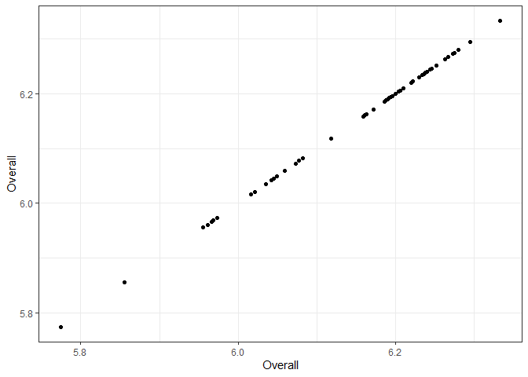

```r
#comprobamos,cómo se distribuyen las distintas variables independientes con respecto de la dependiente, para comprobar linealidad y dispersión.

ggplot(data = pisa_adj, mapping = aes(x = Overall, y = Overall)) +
layer(geom = "point",stat = "identity",position = "identity") +
theme_bw() + theme(legend.key = element_blank())
```

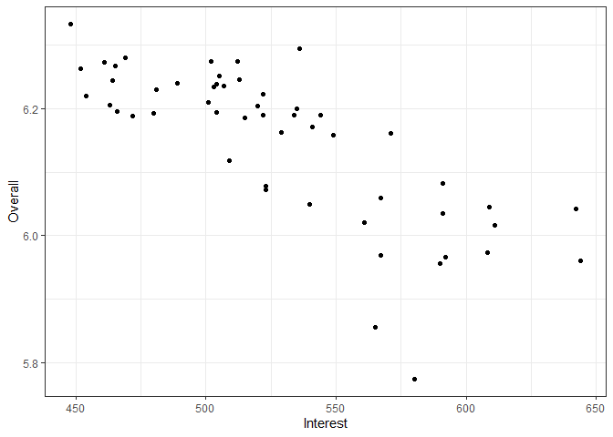

```r
ggplot(data = pisa_adj, mapping = aes(x = Interest, y = Overall)) +
layer(geom = "point",stat = "identity",position = "identity") +
theme_bw() + theme(legend.key = element_blank())
```

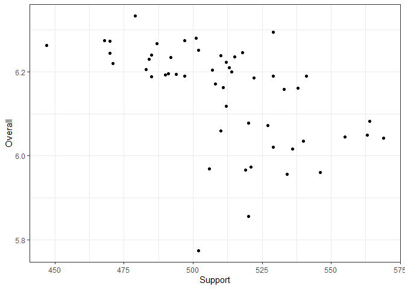

```r
ggplot(data = pisa_adj, mapping = aes(x = Support, y = Overall)) +
layer(geom = "point",stat = "identity",position = "identity") +
theme_bw() + theme(legend.key = element_blank())
```

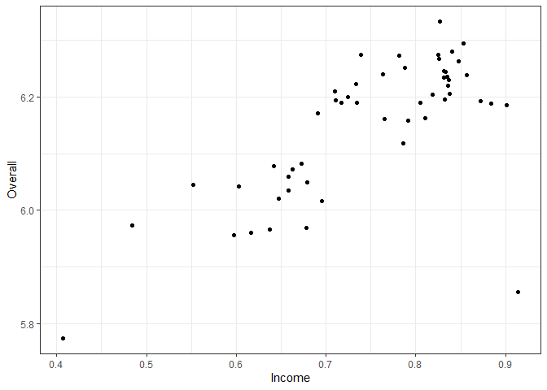

```r
ggplot(data = pisa_adj, mapping = aes(x = Income, y = Overall)) +
layer(geom = "point",stat = "identity",position = "identity") +
theme_bw() + theme(legend.key = element_blank())
```

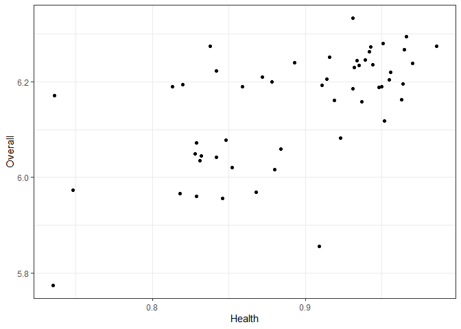

```r
ggplot(data = pisa_adj, mapping = aes(x = Health, y = Overall)) +
layer(geom = "point",stat = "identity",position = "identity") +
theme_bw() + theme(legend.key = element_blank())
```

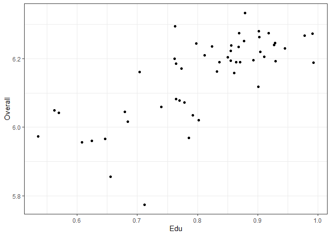

```r
ggplot(data = pisa_adj, mapping = aes(x = Edu, y = Overall)) +
layer(geom = "point",stat = "identity",position = "identity") +
theme_bw() + theme(legend.key = element_blank())
```

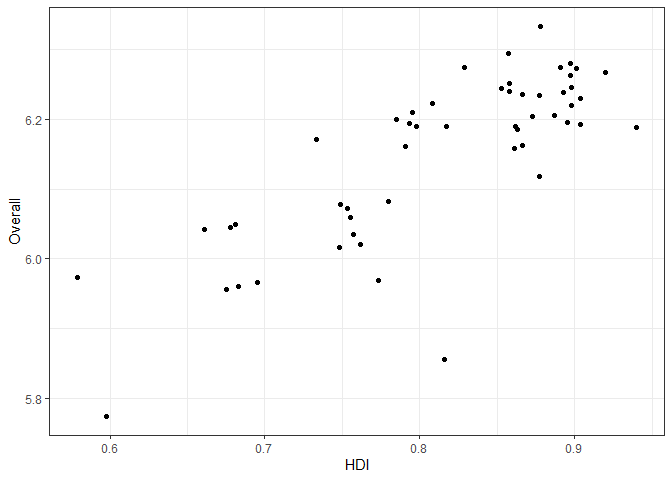

```r
ggplot(data = pisa_adj, mapping = aes(x = HDI, y = Overall)) +
layer(geom = "point",stat = "identity",position = "identity") +
theme_bw() + theme(legend.key = element_blank())
```

En los gráficos se aprecia como todas las variables elegidas para el modelo, menos Overall se distribuyen de forma poco lineal, con valores bastante dispersos

```r
#Modelo lineal

#Comprobamos el modelo lineal con la variable Edu, comparado con la variable dependiente, Overall

lm_mod <- lm(Overall~Edu, data = pisa_adj)

width(flextable(tidy(lm_mod)), width = 1.5)
```

| term | estimate | std.error | statistic | p.value |
| --- | --- | --- | --- | --- |
| (Intercept) | 5.5067044 | 0.08448861 | 65.176886 | 4.957347e-50 |
| Edu | 0.7923238 | 0.10337095 | 7.664859 | 5.503730e-10 |

```r
width(flextable(glance(lm_mod)), width = 1.5)
```

| r.squared | adj.r.squared | sigma | statistic | p.value | df | logLik | AIC | BIC | deviance | df.residual | nobs |
| --- | --- | --- | --- | --- | --- | --- | --- | --- | --- | --- | --- |
| 0.5402302 | 0.5310348 | 0.08311828 | 58.75007 | 5.50373e-10 | 1 | 56.58444 | -107.1689 | -101.3152 | 0.3454325 | 50 | 52 |

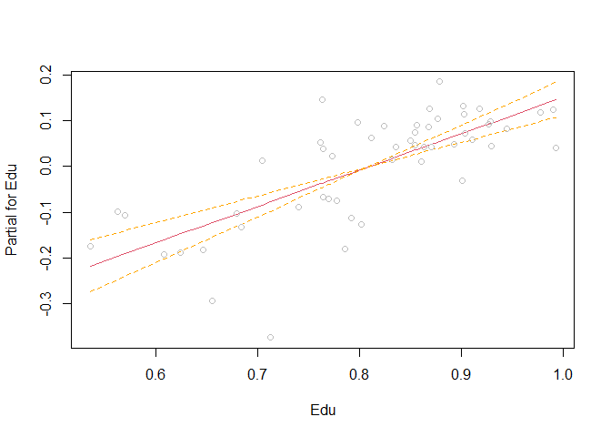

```r
#visualización del modelo para verlo de forma más gráfica y apreciar su distribución.

termplot(lm_mod, partial.resid = TRUE, se = TRUE)
```

La variable es poco lineal, como se apreció anteriormente, es decir los puntos no se encuentran pegados a la línea.

## GAM

### Modelo GAM 1

Realizamos la primera muestra GAM utilizando todos los regresores que figuran en nuestro modelo utilizando como variable dependiente ‘overall’

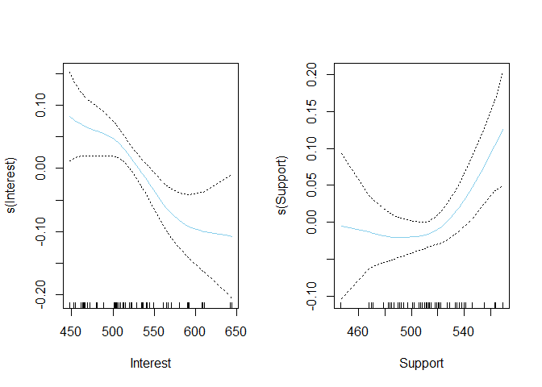

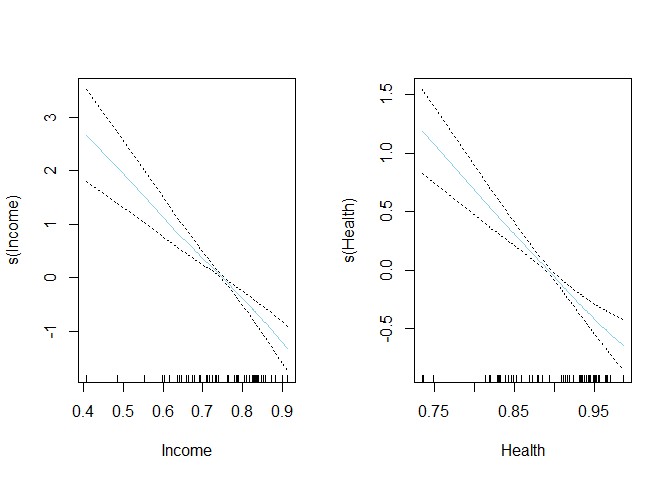

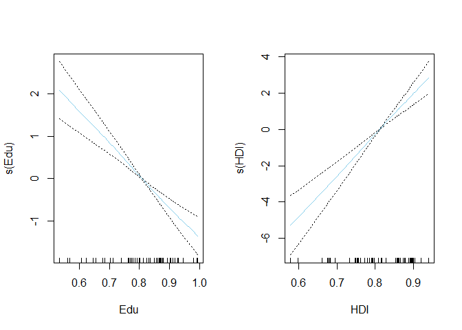

```r
#Modelo 1 GAM, con todos los splines de todas las variables del modelo

gam_1 <- gam(Overall ~ s(Interest) +s(Support)+ s(Income) +s(Health) + s(Edu) + s(HDI), data = pisa_adj)

#Utilizamos la función par con el parámetro mfrow para dividir la ventana gráfica en forma de matriz, y almacenar así en cada celda un gráfico diferente, siendo 1 el número de filas, y 2 el número de columnas en las cuales se va a dividir la ventana gráfica.

par(mfrow = c(1,2))
plot(gam_1, se=T, col='skyblue')
```

```r
summary(gam_1)
```

```
##
## Call: gam(formula = Overall ~ s(Interest) + s(Support) + s(Income) +
##     s(Health) + s(Edu) + s(HDI), data = pisa_adj)
## Deviance Residuals:
##       Min        1Q    Median        3Q       Max
## -0.099180 -0.022846  0.001733  0.027128  0.102764
##
## (Dispersion Parameter for gaussian family taken to be 0.0026)
##
##     Null Deviance: 0.7513 on 51 degrees of freedom
## Residual Deviance: 0.07 on 27.0005 degrees of freedom
## AIC: -144.2034
##
## Number of Local Scoring Iterations: NA
##
## Anova for Parametric Effects
##             Df  Sum Sq Mean Sq  F value    Pr(>F)
## s(Interest)  1 0.40584 0.40584 156.6207 9.431e-13 ***
## s(Support)   1 0.03257 0.03257  12.5710 0.0014526 **
## s(Income)    1 0.03747 0.03747  14.4595 0.0007444 ***
## s(Health)    1 0.00002 0.00002   0.0096 0.9226210
## s(Edu)       1 0.01722 0.01722   6.6467 0.0157092 *
## s(HDI)       1 0.11033 0.11033  42.5777 5.368e-07 ***
## Residuals   27 0.06997 0.00259
## ---
## Signif. codes:  0 '***' 0.001 '**' 0.01 '*' 0.05 '.' 0.1 ' ' 1
##
## Anova for Nonparametric Effects
##             Npar Df Npar F   Pr(F)
## (Intercept)
## s(Interest)       3 1.6985 0.19091
## s(Support)        3 3.2390 0.03762 *
## s(Income)         3 2.5957 0.07305 .
## s(Health)         3 1.2379 0.31530
## s(Edu)            3 2.0264 0.13387
## s(HDI)            3 3.3376 0.03405 *
## ---
## Signif. codes:  0 '***' 0.001 '**' 0.01 '*' 0.05 '.' 0.1 ' ' 1
```

En primer lugar, aparecen como las variables más dependientes, teniendo en cuenta los splines, Interest, Support, Income y HDI.

En segundo lugar, aparecen como las únicas variables un poco más dependientes, según anova, SUpport y HDI.

### Modelo GAM 2

Segundo modelo de GAM sin splines, para comprobar el cambio

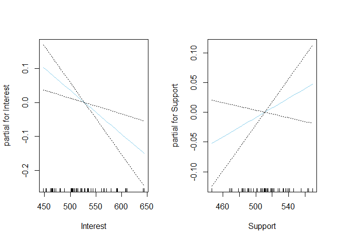

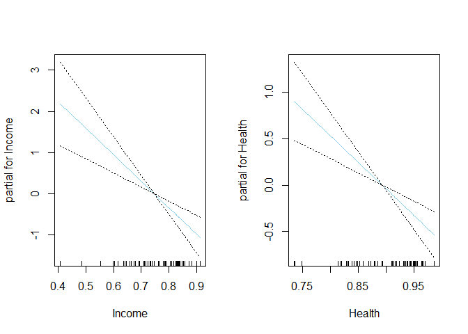

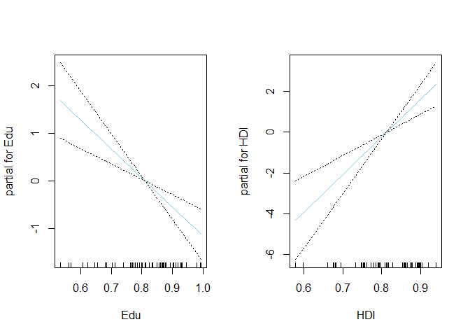

```r
gam_2 <- gam(Overall ~ Interest +Support+ Income + Health + Edu + HDI, data = pisa_adj)

par(mfrow = c(1,2))
plot(gam_2, se=T, col='skyblue')
```

```r
summary(gam_2)
```

```
##
## Call: gam(formula = Overall ~ Interest + Support + Income + Health +
##     Edu + HDI, data = pisa_adj)
## Deviance Residuals:
##       Min        1Q    Median        3Q       Max
## -0.119507 -0.047629  0.002477  0.038848  0.136202
##
## (Dispersion Parameter for gaussian family taken to be 0.0037)
##
##     Null Deviance: 0.7513 on 51 degrees of freedom
## Residual Deviance: 0.1646 on 45 degrees of freedom
## AIC: -135.7178
##
## Number of Local Scoring Iterations: 2
##
## Anova for Parametric Effects
##           Df  Sum Sq Mean Sq  F value    Pr(>F)
## Interest   1 0.44495 0.44495 121.6510 2.211e-14 ***
## Support    1 0.02077 0.02077   5.6794  0.021448 *
## Income     1 0.02669 0.02669   7.2974  0.009701 **
## Health     1 0.00375 0.00375   1.0245  0.316856
## Edu        1 0.01752 0.01752   4.7904  0.033849 *
## HDI        1 0.07304 0.07304  19.9692 5.268e-05 ***
## Residuals 45 0.16459 0.00366
## ---
## Signif. codes:  0 '***' 0.001 '**' 0.01 '*' 0.05 '.' 0.1 ' ' 1
```

Pierden significancia algunas variables sin los splines y Health sigue sin ser significante según el test Anova

## Conclusión

Las variables estudiadas, en general se han distribuido con bastante dispersión. Mediante el uso del modelo GAM, se han podido afirmar esto mismo, pero además, el uso de los splines en este caso podría ser relevante porque a priori, las variables parecen no seguir una linealidad clara.

Por eso mismo, este método reduciría la complejidad de la realización del modelo. Se puede apreciar en las gráficas con splines cómo ajustarían en cierto modo el modelo en la mejoría de significancia del ajuste.